# Playing with a Full Deque

Oliver Keyes

June 03, 2017

# Who?

# Me!

- Itinerant munger
- Incoming UW PhD
- They/Them

# Background

- Many, many packages
- Long-time R/C++ dev
- sometimes competent

# What is this?

# Speedups for your speedups

- Ways of making your C++ *even faster and more reliable*
- Assumes some Rcpp knowledge
- Standard C++, *not* Rcpp

# Rejected titles

- A Benchmark Too Far
- Honey I Shrunk the Runtime
- POINTER DEREFERENCING! The Musical

# Vectors and Deques

# Vectors

- C++ has vectors, just like R (and Rcpp!)
- Everyone uses them

# And then bad stuff happens

```cpp
std::vector < std::string > uh_oh;

for(unsigned int i = 0; i < 1000000; i++){

    uh_oh.push_back("noooooo*gurgle**gurgle**dies*");

}
```

- Vectors are contiguous - and so expanding them is expensive.
- Appending expands them.

# Solution 1: preallocation!

- If you know the ultimate length of a vector: preallocate.
- One allocation for 1m elements instead of 1m allocations.

```cpp
int input_size = 1000000;

std::vector < std::string > preallocated_vector(vector_size);

for(unsigned int i = 0; i < input_size; i++){

    preallocated_vector[i] = "Watch us fly!";

}
```

# Solution 2: Deques!

- If you don’t know the ultimate length, use deques
- Non-contiguous memory - cheaper to append to
- Still slower than preallocation

```cpp
int input_size = 1000000;

std::deque < std::string > a_deque;

for(unsigned int i = 0; i < input_size; i++){

    a_deque.push_back("This works pretty well");

}
```

# Final proof

- 1m inserts to: – Preallocated vector – Non-allocated vector – Non-allocated deque
- Result:

# TADA

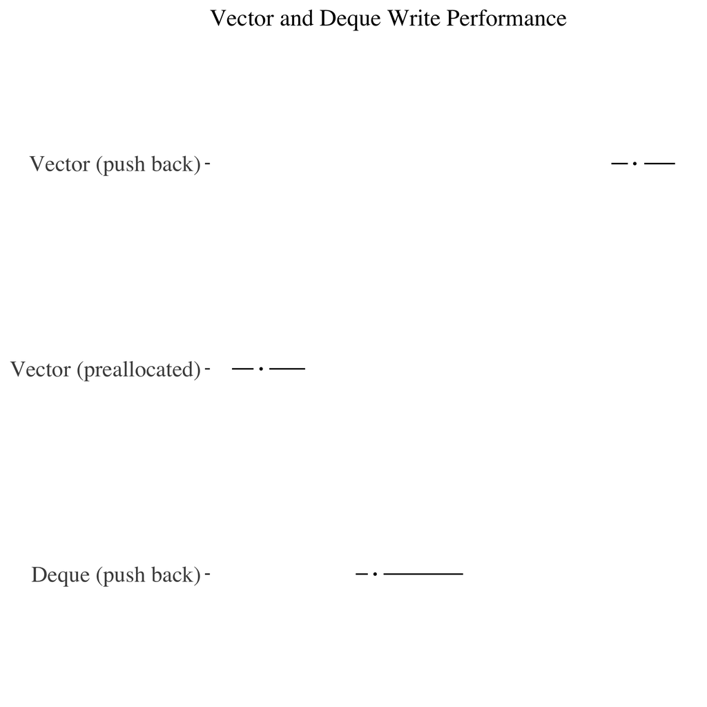

# Pointers and References

# Pointers

- In C++ you can pass a ‘pointer’ instead of a value
- The pointer ‘points’ to the value
- Modify the pointer? Modifies the value!

```
int* pointer;
int value, value2;

pointer = &value;

*pointer = 10; // value is 10

pointer = &value2;

*pointer = 10; // value2 is 10
```

# Pointer pointers

- Pointers can be NULL, and then everything breaks
- Confusing awful syntax
- No.
- No No.

# References!

- Similar to pointers
- Only one possible value
- Can’t be NULL
- Less eyeball-searing syntax

```
int value, value2;

int& reference = value;

reference = 10; // value is 10

int& reference2 = value2;

reference2 = 10; // value2 is 10
```

# Use one, Prefer References

- Passing by reference/pointer > passing object (mostly)
- References are safer
- Edge case: if you need it to be null maybe

# Operators

# Operator choice matters

- As well as `+`, `=`, `*`, etc, etc, C++ has `+=`, `-=`, `*=`.
- Use these wherever possible

```cpp
int x = 1;

// Less efficient
x = (x + 10);

// More efficient!
x += 10;
```

# Eh?

# Misc

# General principles

- Pick containers judiciously
- Never make a new object when you don’t have to
- Don’t compromise readability

# Other ideas

Things I couldn’t fit in but might be useful:

- Other standard containers
- Function inlining (and use)
- Switches versus conditionals
- If you still want ideas on performance improvements - google!
- Or ask me after